# Replication of Neural affective mechanisms predict market-level microlending by Genevsky & Knutson (2015, Psychological Science)

Lester Tong (lctong@stanford.edu)

March 25, 2017

## Introduction

This is a replication of the Internet study described in Genevsky & Knutson (2015). The original study asked about the relative contribution of different features of microloan requests to funding success. The study focused on affective features and modality, including the affective quality of the faces of the microloan recipients, and the text used in the description. The original paper found that affective ratings of microloan recipient faces in an independent Internet sample could be used to predict the rate at which a microloan received funding. Thus, the result I aim to replicate is the significant linear effect of rated facial positive arousal on the aggregate funding rate.

## Methods

Participants are asked to view 20 images and rate each of them on the following dimensions: how clear the image is, affective valence, affective arousal, discrete emotion, emotion intensity, and neediness.

### Power Analysis

The original analysis was a mixed-effects model, so it is not straightforward to devise an exact power analysis. Instead, I used simulation on the original data, by running the primary analysis of interest on random (without replacement) smaller subsamples of the data, where a “success” is a significant coefficient on the positive arousal regressor, I found that I could obtain power of 0.80 using random samples of 2800 images.

I conducted a sweep using different sample sizes of images by modifying `nsubjs` in the code below and simulating 1000 samples:

```r
## load outcome data
dana1 <- read.csv("kiva_aggdata.csv")

nsubjs=2800
nsamps=1000;
successes=0; ## start at zero
for(i in 1:nsamps){
  ## sample
  subsamp=sample(7000,nsubjs)
  mod1 <- lmer(logdollarhour ~ scale(per_posemo) + scale(per_negemo) + scale(pa_orig) + scale(na_orig) +
                 scale(cansee_orig) + scale(need_orig) +
                 scale(total_words_in_description) +
                 scale(loan_amount) + scale(terms_2_repayment_term) +
                 gender + (1|sector) + (1|location_3_country_code), data=dana1[subsamp,])
  ## count successes
  if(summary(mod1)$coefficients[4,5]<0.05){ ## coefficient on positive arousal
    successes=successes+1;
  }
}
success=successes/nsamps
print(paste("Proportion of successes: ",success))
```

```
## [1] "Proportion of successes:  0.806"
```

### Planned Sample

Planned sample size is 2800 images, at 20 images per subject, this requires a sample of 140 subjects.

### Materials

“We acquired extensive data on microloan outcomes from Kiva Microfunds (www.kiva.org), an Internet-based international microfinance organization. Kiva’s Web site allows users to offer small financial loans to individuals in need. Loans are funded in $25 increments but are received by the borrower only if the requested amount is successfully raised within 30 days of the initial loan request. We first used the Kiva application programming interface to sample 144,769 loan requests from those posted during the 2012 calendar year, the most recent period that could ensure complete loan-outcome results at the time of initial analyses. We then excluded loan requests with multiple borrowers (remaining n = 127,811), to minimize heterogeneity in photograph ratings arising from variations in the size of the borrower group; loan requests without text (remaining n = 120,130), because they could not be scored with respect to affective words in the text; (c) loan requests that were fully funded within the last 3 days of eligibility (remaining n = 109,454), to limit potential confounds due to shifts in lender’s motiva- tions and behavior as the deadline for loan expiration approached; and (d) loan requests with additional miss- ing data points (remaining n = 91,858). Of the remaining 91,858 loan requests, 13,500 were randomly sampled for analysis (i.e., 7,000 funded and 6,500 not funded).”

Note that while the original study included 7000 microloans that were funded, we are randomly sampling a subset of 2800 images from the original stimulus set. The subset will not be preselected (as MTurk participants accept the HIT, samples of images will be taken without replacement from the superset).

### Procedure

“The affective impact of the loan-request photographs was estimated by soliciting independent ratings on Ama- zon’s Mechanical Turk. All raters gave informed consent prior to participating. Each rater viewed a randomly selected photograph extracted from one of the Kiva loan requests and then evaluated the photograph on 7-point scales indexing the affective valence and arousal sig- naled by the person’s facial expression, the photograph’s identifiability (or visual clarity), and the person’s per- ceived neediness. A forced-choice question then asked raters to categorize the emotion displayed (i.e., whether the person was happy, sad, calm, fearful, angry, dis- gusted, etc.; see Fig. S1 in the Supplemental Material). To ensure that ratings referred only to the photographs and not other details on the loan-request pages, we pre- sented the photographs alone, removed from the con- text of the loan requests.”

### Analysis Plan

The key analysis is as follows:

We will conduct a mixed model using random intercepts for sector, and location country code, corresponding to the regression table presented in Table 1 of the original manuscript. The dependent variable will be the logarithm of the rate at which a microloan gets funded. The fixed effects will include: positive emotion words in the description, negative emotion words in the description, positive arousal, negative arousal, clarity of the image, perceived neediness, number of words in loan description, loan amount requested, repayment term, and requestee gender.

This model structure is identical to the analysis in the original study, which was used in the power analysis above.

A successful replication would require a significant (positive) coefficient on positive arousal.

### Differences from Original Study

One important difference is that in the current replication, participants are explicitly asked to make 20 ratings, while in the original study, participants could choose to rate between 1 and 50 loan request images.

The analysis also uses one MTurker rating per image, rather than two MTurker ratings per image.

Finally, I added zero variance responses as an exclusion criterion, which was not an exclusion criterion in the original study.

These differences are not anticipated to have an effect on the main result.

### Methods Addendum (Post Data Collection)

#### Actual Sample

The sample included 140 MTurk workers, with approval rate greater than 95% and location in the US. None were excluded.

Of the 140 MTurkers, 93 were male and 47 were female. The vast majority (79%) identified as white. Ages ranged from 20-66 (m: 37.92, sd: 10.27).

#### Differences from pre-data collection methods plan

The only noteworthy feature that was not included in the preregistration were the qualifications required of MTurk workers (95% approval rate and US location).

## Results

### Data preparation

Data preparation following the analysis plan.

```r
###Data Preparation

####Import data

## load mturk json files
hits=list.dirs(path="./final_data",recursive=F)
data=list()
for (f in hits){
files=list.files(paste(f,"/production-results-anonymized-results/", sep=""),pattern=".json")
  for (i in files){
    data[[length(data)+1]]=fromJSON(paste(f,"/production-results-anonymized-results/",i,sep=""))
  }
}
## pull relevant data from json files
image_0_id=c();valence=c();arousal=c();cansee=c();need=c();comments=c();subj=c();age=c();race=c();gender=c();
for (i in 1:length(data)){
subj=c(subj,data[[i]]$AssignmentId);
image_0_id=c(image_0_id,as.numeric(data[[i]]$answers$data$orderArray));
valence=c(valence,data[[i]]$answers$data$valence);
arousal=c(arousal,data[[i]]$answers$data$arousal);
cansee=c(cansee,data[[i]]$answers$data$clear);
need=c(need,data[[i]]$answers$data$need);
comments=c(comments,data[[i]]$answers$data$comments);
age=c(age,data[[i]]$answers$data$age);
race=c(race,data[[i]]$answers$data$race);
gender=c(gender,data[[i]]$answers$data$gender);
}
mturkdata=data.frame(subj,image_0_id,valence,arousal,cansee,need,comments)

mturkdemo=data.frame(subj,age,race,gender)

### quick descriptive stats:
summary(mturkdemo$race)/20 ## 20 trials per subject
```

```
##  amind  asian  black hawaii   hisp  white
##   0.10   0.50   0.35   0.05   0.45   5.55
```

```r
summary(mturkdemo$gender)/20
```

```
##    F    M
## 2.35 4.65
```

```r
age_dist <- mturkdemo %>%
  group_by(subj) %>%
  summarize(age=mean(as.numeric(as.character(age)),na.rm=TRUE))
summary(age_dist)
```

```
##                              subj          age
##  30BXRYBRP4XEAU6SA2KLU8EWJ32WHF:  1   Min.   :20.00
##  30BXRYBRP4XEAU6SA2KLU8EWJ3ZHWX:  1   1st Qu.:29.00
##  31IBVUNM9SZHH9FHP2RP5LJ5WFKFVN:  1   Median :36.00
##  31Q0U3WYDPFOG4KD059OA5Z89NU17G:  1   Mean   :37.92
##  320DUZ38G7ME4EBIJXJOKI8N27DGJ2:  1   3rd Qu.:44.25
##  323Q6SJS8IGCZ8KXKDALQKSWO09FHX:  1   Max.   :66.00
##  (Other)                       :134
```

```r
sd(age_dist$age)
```

```
## [1] 10.27189
```

```r
#### Data exclusion / filtering

# find subjects who responded with zero variance on any question
mturkdata_var = mturkdata %>%
  group_by(subj) %>%
  summarise(var_valence=var(valence,na.rm=TRUE),var_arousal=var(arousal,na.rm=TRUE),var_cansee=var(cansee,na.rm=TRUE),var_need=var(need,na.rm=TRUE))
subj_ex=mturkdata_var[mturkdata_var$var_valence==0 | mturkdata_var$var_arousal==0 | mturkdata_var$var_cansee==0 | mturkdata_var$var_need==0,]$subj
# keep subjects with nonzero variance
mturkdata=mturkdata[!(mturkdata$subj %in% subj_ex),]

#### Prepare data for analysis - create columns etc.

## combine MTurk ratings with out of sample data, drop rows for images that were not rated on MTurk
merged_data=full_join(mturkdata,dana1) %>%
  filter(!is.na(subj))
## generate positive arousal and negative arousal variables, these should be ipsatized, following Knutson, Katovich, & Suri (TICS 2014), but in the original table in the paper they are not
merged_data = merged_data %>%
  group_by(subj) %>%
  mutate(val_ip=as.numeric(scale(valence,scale=F)),aro_ip=as.numeric(scale(arousal,scale=F)),see_ip=as.numeric(scale(cansee,scale=F)),need_ip=as.numeric(scale(need,scale=F))) %>% # ipsatize variables
  ungroup() %>%
  mutate(pa=arousal/sqrt(2)+valence/sqrt(2),na=arousal/sqrt(2)-valence/sqrt(2), pa_ip=aro_ip/sqrt(2)+val_ip/sqrt(2),na_ip=aro_ip/sqrt(2)-val_ip/sqrt(2)) # rotate axes


## average over observations with the same PA value for plotting figure 2b
summarized_data = merged_data %>%
  filter(!is.na(logdollarhour)) %>%
  group_by(pa) %>%
  summarize(mean_logdollarhour=mean(logdollarhour),se_logdollarhour=sd(logdollarhour)/sqrt(length(logdollarhour)))

## main analysis 1, (table 1)
mod1 <- lmer(logdollarhour ~ scale(per_posemo) + scale(per_negemo) + scale(pa) + scale(na) +
               scale(see_ip) + scale(need_ip) +
               scale(total_words_in_description) +
               scale(loan_amount) + scale(terms_2_repayment_term) +
               gender + (1|sector) + (1|location_3_country_code), data=merged_data)
## fixed effect table without df column
tidy_table<-summary(mod1)$coefficients[,-3]
rownames(tidy_table)=c("Intercept","Text: positive words (%)","Text: negative words (%)","Photo: positive arousal","Photo: negative arousal","Photo: identifiability","Borrower's neediness","Text: total number of words","Requested loan amount","Repayment term","Borrower's sex")

tidy_table<-as.data.frame(tidy_table) %>%
  rownames_to_column("Param")

## main analysis 2, (figure 2b)
fig2b_rep=ggplot(summarized_data, aes(x=pa,y=mean_logdollarhour)) +
  geom_point(size=2) +
  geom_errorbar(aes(ymax=mean_logdollarhour+se_logdollarhour,ymin=mean_logdollarhour-se_logdollarhour, width=0.2))+
  geom_smooth(method="lm",se=F) +
  labs(x = "Positive Arousal", y = "Aggregate Lending Rate (log($/hr))")+
  ylim(0,5)+
  ggtitle("Figure 2b Replication")
```

### Confirmatory analysis

The main analysis to replicate in the original paper was the significant positive coefficient on positive arousal in Table 1. Figure 2b in the original paper provides a visualization of this result. The original figure together with a version using the replication data are also presented below.

## Table 1 Replication

```r
kable(tidy_table,digits=3,col.names=c("Param","B","SE","t","p"))
```

| Param | B | SE | t | p |
| --- | --- | --- | --- | --- |
| Intercept | 4.518 | 0.290 | 15.575 | 0.000 |
| Text: positive words (%) | 0.039 | 0.031 | 1.264 | 0.206 |
| Text: negative words (%) | -0.006 | 0.031 | -0.182 | 0.856 |
| Photo: positive arousal | 0.047 | 0.031 | 1.513 | 0.130 |
| Photo: negative arousal | 0.018 | 0.031 | 0.571 | 0.568 |
| Photo: identifiability | 0.038 | 0.031 | 1.249 | 0.212 |
| Borrower’s neediness | -0.056 | 0.031 | -1.803 | 0.071 |
| Text: total number of words | 0.003 | 0.036 | 0.076 | 0.939 |
| Requested loan amount | 0.021 | 0.041 | 0.515 | 0.606 |
| Repayment term | -0.277 | 0.043 | -6.476 | 0.000 |
| Borrower’s sex | -0.752 | 0.075 | -10.046 | 0.000 |

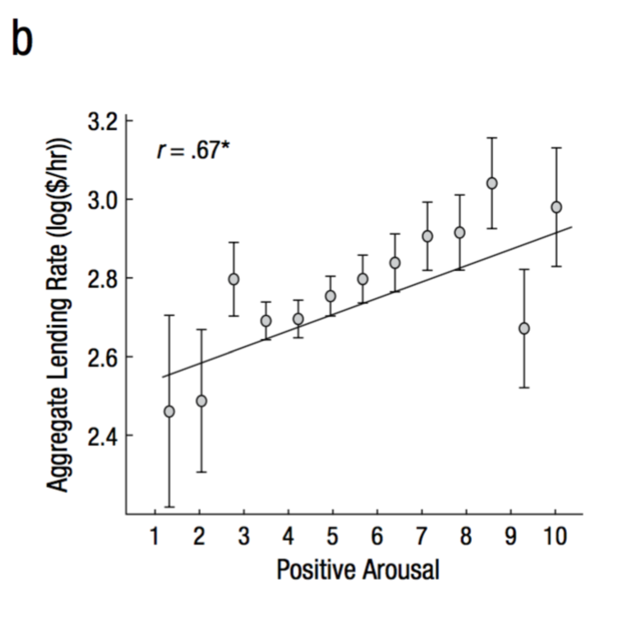

Original Figure 2B of Genevsky & Knutson (2015)

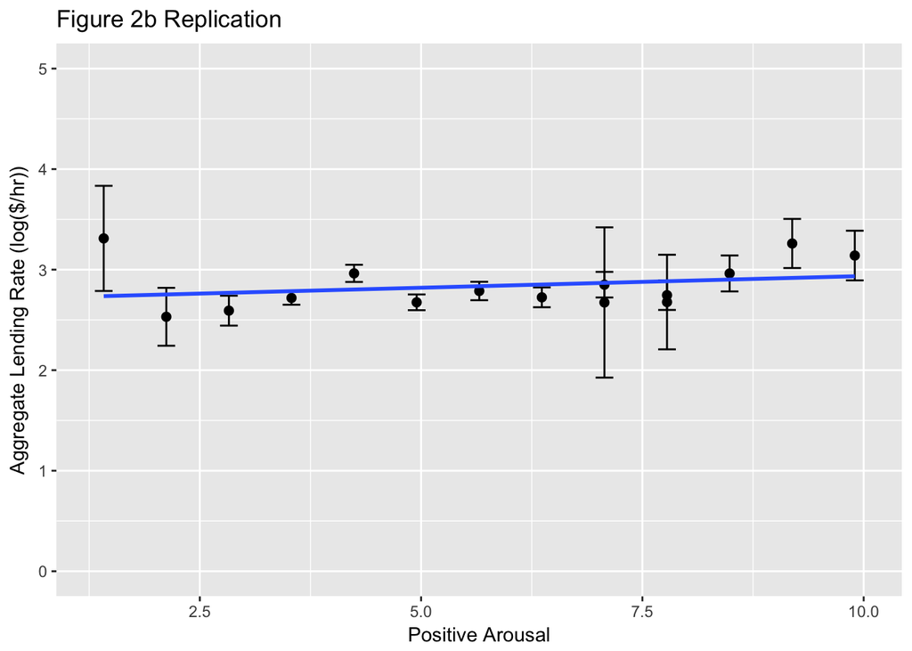

### Exploratory analyses

In addition to the primary analysis, the following analysis was also described in the preregistration, but not implemented in the original article:

> Adding subject random intercepts (not done in original manuscript). Ipsatizing affect variables before PA/NA rotation.

Ipsatizing the affect measurements (valence and arousal) is an integral part of the procedure advocated in Knutson, Katovich, & Suri (TICS, 2014) for rotating the valence and arousal axes to align with positive and negative arousal.

```r
mod2 <- lmer(logdollarhour ~ scale(per_posemo) + scale(per_negemo) +
               scale(pa_ip) + scale(na_ip) +
               scale(see_ip) + scale(need_ip) +
               scale(total_words_in_description) +
               scale(loan_amount) + scale(terms_2_repayment_term) +
               gender + (1|sector) + (1|location_3_country_code) + (1|subj), data=merged_data)
## fixed effect table without df column
tidy_table2<-summary(mod2)$coefficients[,-3]
rownames(tidy_table2)=c("Intercept","Text: positive words (%)","Text: negative words (%)","Photo: positive arousal","Photo: negative arousal","Photo: identifiability","Borrower's neediness","Text: total number of words","Requested loan amount","Repayment term","Borrower's sex")

tidy_table2<-as.data.frame(tidy_table2) %>%
  rownames_to_column("Param")
kable(tidy_table2,digits=3,col.names=c("Param","B","SE","t","p"))
```

| Param | B | SE | t | p |
| --- | --- | --- | --- | --- |
| Intercept | 4.519 | 0.290 | 15.568 | 0.000 |
| Text: positive words (%) | 0.039 | 0.031 | 1.257 | 0.209 |
| Text: negative words (%) | -0.005 | 0.031 | -0.179 | 0.858 |
| Photo: positive arousal | 0.055 | 0.031 | 1.762 | 0.078 |
| Photo: negative arousal | 0.001 | 0.031 | 0.042 | 0.966 |
| Photo: identifiability | 0.037 | 0.031 | 1.214 | 0.225 |
| Borrower’s neediness | -0.051 | 0.031 | -1.650 | 0.099 |
| Text: total number of words | 0.003 | 0.036 | 0.070 | 0.944 |
| Requested loan amount | 0.020 | 0.041 | 0.494 | 0.621 |
| Repayment term | -0.277 | 0.043 | -6.482 | 0.000 |
| Borrower’s sex | -0.753 | 0.075 | -10.060 | 0.000 |

Finally, just as a potentially informative comparison, here is the same model fitted on the original data from Genevsky & Knutson (2015).

```r
mod3 <- lmer(logdollarhour ~ scale(per_posemo) + scale(per_negemo) +
               scale(pa_orig) + scale(na_orig) +
               scale(see_ip) + scale(need_ip) +
               scale(total_words_in_description) +
               scale(loan_amount) + scale(terms_2_repayment_term) +
               gender + (1|sector) + (1|location_3_country_code) + (1|subj), data=merged_data)
## fixed effect table without df column
tidy_table3<-summary(mod3)$coefficients[,-3]
rownames(tidy_table3)=c("Intercept","Text: positive words (%)","Text: negative words (%)","Photo: positive arousal","Photo: negative arousal","Photo: identifiability","Borrower's neediness","Text: total number of words","Requested loan amount","Repayment term","Borrower's sex")

tidy_table3<-as.data.frame(tidy_table3) %>%
  rownames_to_column("Param")
kable(tidy_table3,digits=3,col.names=c("Param","B","SE","t","p"))
```

| Param | B | SE | t | p |
| --- | --- | --- | --- | --- |
| Intercept | 4.516 | 0.292 | 15.460 | 0.000 |
| Text: positive words (%) | 0.032 | 0.031 | 1.045 | 0.296 |
| Text: negative words (%) | -0.003 | 0.031 | -0.107 | 0.915 |
| Photo: positive arousal | 0.076 | 0.031 | 2.452 | 0.014 |
| Photo: negative arousal | -0.036 | 0.030 | -1.199 | 0.231 |
| Photo: identifiability | 0.040 | 0.031 | 1.307 | 0.191 |
| Borrower’s neediness | -0.047 | 0.030 | -1.554 | 0.120 |
| Text: total number of words | 0.000 | 0.036 | -0.007 | 0.994 |
| Requested loan amount | 0.022 | 0.041 | 0.532 | 0.595 |
| Repayment term | -0.281 | 0.043 | -6.573 | 0.000 |
| Borrower’s sex | -0.748 | 0.075 | -9.949 | 0.000 |

## Discussion

### Summary of Replication Attempt

Despite not replicating in the new sample, the subsample of images used in this replication would have shown a significant association in the original sample. This calls into question the reliability of using just one (or two) raters to estimate the population norm. Another possibility is that explicitly making the replication a repeated measures design reduces the variability of affect ratings because subjects attempt to be consistent while the stimuli themselves may not appear to vary that much.